# Session 2: Homework 1

Study Group 7

2022-09-04

# 1 Rents in San Francsisco 2000-2018

```r
# download directly off tidytuesdaygithub repo

rent <- readr::read_csv('https://raw.githubusercontent.com/rfordatascience/tidytuesday/master/data/2022/2022-07-05/rent.csv')
```

What are the variable types? Do they all correspond to what they really are? Which variables have most missing values?

This dataset has 2 different types of data sets - character and double. All the variables correspond to the respective data types. The character data type is used for all text based variables like city, country, etc and the double precision data type is used for numeric and date variables. ‘descr’ has the most missing value, 197542. ‘adress’ has the second most missing value, of 196888.

```r
skimr::skim(rent)
```

Data summary

| Name | rent |
| --- | --- |
| Number of rows | 200796 |
| Number of columns | 17 |
| _______________________ |  |
| Column type frequency: |  |
| character | 8 |
| numeric | 9 |
| ________________________ |  |
| Group variables | None |

**Variable type: character**

| skim_variable | n_missing | complete_rate | min | max | empty | n_unique | whitespace |
| --- | --- | --- | --- | --- | --- | --- | --- |
| post_id | 0 | 1.00 | 9 | 14 | 0 | 200796 | 0 |
| nhood | 0 | 1.00 | 4 | 43 | 0 | 167 | 0 |
| city | 0 | 1.00 | 5 | 19 | 0 | 104 | 0 |
| county | 1394 | 0.99 | 4 | 13 | 0 | 10 | 0 |
| address | 196888 | 0.02 | 1 | 38 | 0 | 2869 | 0 |
| title | 2517 | 0.99 | 2 | 298 | 0 | 184961 | 0 |
| descr | 197542 | 0.02 | 13 | 16975 | 0 | 3025 | 0 |
| details | 192780 | 0.04 | 4 | 595 | 0 | 7667 | 0 |

**Variable type: numeric**

| skim_variable | n_missing | complete_rate | mean | sd | p0 | p25 | p50 | p75 | p100 | hist |
| --- | --- | --- | --- | --- | --- | --- | --- | --- | --- | --- |
| date | 0 | 1.00 | 2.01e+07 | 44694.07 | 2.00e+07 | 2.01e+07 | 2.01e+07 | 2.01e+07 | 2.02e+07 | ▁▇▁▆▃ |
| year | 0 | 1.00 | 2.01e+03 | 4.48 | 2.00e+03 | 2.00e+03 | 2.01e+03 | 2.01e+03 | 2.02e+03 | ▁▇▁▆▃ |
| price | 0 | 1.00 | 2.14e+03 | 1427.75 | 2.20e+02 | 1.30e+03 | 1.80e+03 | 2.50e+03 | 4.00e+04 | ▇▁▁▁▁ |
| beds | 6608 | 0.97 | 1.89e+00 | 1.08 | 0.00e+00 | 1.00e+00 | 2.00e+00 | 3.00e+00 | 1.20e+01 | ▇▂▁▁▁ |
| baths | 158121 | 0.21 | 1.68e+00 | 0.69 | 1.00e+00 | 1.00e+00 | 2.00e+00 | 2.00e+00 | 8.00e+00 | ▇▁▁▁▁ |
| sqft | 136117 | 0.32 | 1.20e+03 | 5000.22 | 8.00e+01 | 7.50e+02 | 1.00e+03 | 1.36e+03 | 9.00e+05 | ▇▁▁▁▁ |
| room_in_apt | 0 | 1.00 | 0.00e+00 | 0.04 | 0.00e+00 | 0.00e+00 | 0.00e+00 | 0.00e+00 | 1.00e+00 | ▇▁▁▁▁ |
| lat | 193145 | 0.04 | 3.77e+01 | 0.35 | 3.36e+01 | 3.74e+01 | 3.78e+01 | 3.78e+01 | 4.04e+01 | ▁▁▅▇▁ |
| lon | 196484 | 0.02 | -1.22e+02 | 0.78 | -1.23e+02 | -1.22e+02 | -1.22e+02 | -1.22e+02 | -7.42e+01 | ▇▁▁▁▁ |

```r
spec(rent)
unique(rent$city)
```

```
##   [1] "alameda"             "san francisco"       "el cerrito"
##   [4] "san jose"            "american canyon"     "atherton"
##   [7] "belmont"             "ben lomond"          "berkeley"
##  [10] "boulder cr"          "brentwood"           "brisbane"
##  [13] "brookdale"           "burlingame"          "calistoga"
##  [16] "campbell"            "soquel"              "cazadero"
##  [19] "clayton"             "cloverdale"          "pescadero"
##  [22] "colma"               "concord"             "corralitos"
##  [25] "corte madera"        "crockett"            "cupertino"
##  [28] "daly city"           "san ramon"           "dillon beach"
##  [31] "winters"             "dublin"              "east bay"
##  [34] "emeryville"          "fairfax"             "fairfield"
##  [37] "felton"              "forest knolls"       "foster city"
##  [40] "geyserville"         "gilroy"              "cordelia"
##  [43] "greenbrae"           "guerneville"         "half moon bay"
```

[output cut: 20 more lines]

Make a plot that shows the top 20 cities in terms of % of classifieds between 2000-2018. You need to calculate the number of listings by city, and then convert that number to a %.

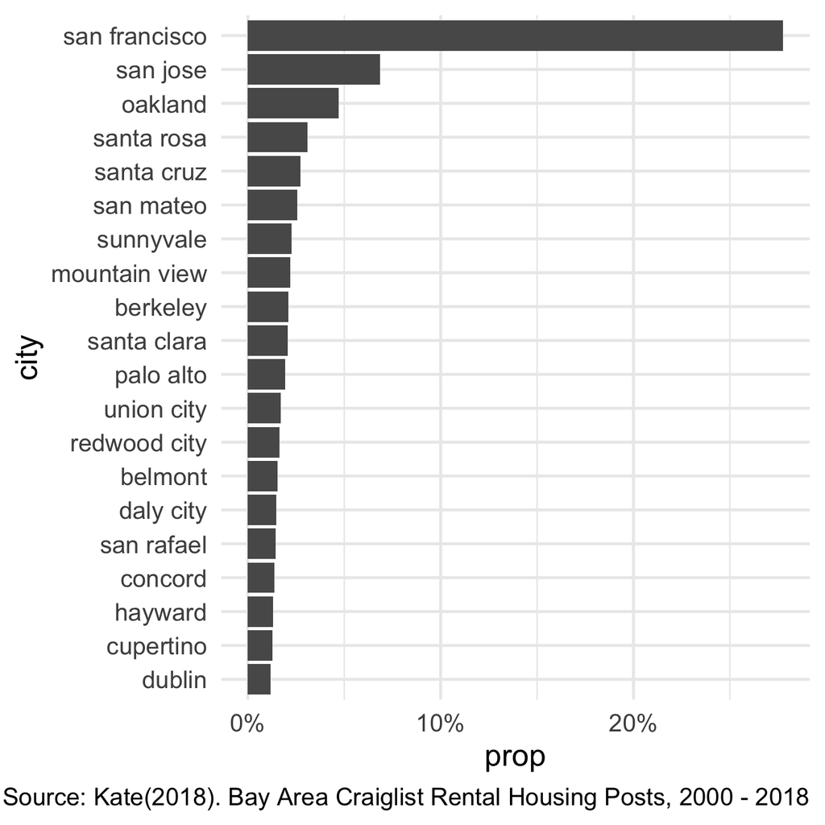

```r
rent %>%
  count(city, sort=TRUE) %>%
  mutate(prop = n/sum(n)) %>%
  slice_max(n= 20, order_by= prop) %>%
  mutate(city = fct_reorder(city,prop)) %>%
  ggplot(aes(x= prop, y= city))+
  geom_col()+
  theme_minimal(base_size = 18)+
  scale_x_continuous(labels = scales::percent)+labs (x = 'prop', y = 'city', caption = "Source: Kate(2018). Bay Area Craiglist Rental Housing Posts, 2000 - 2018")
```

Make a plot that shows the evolution of median prices in San Francisco for 0, 1, 2, and 3 bedrooms listings.

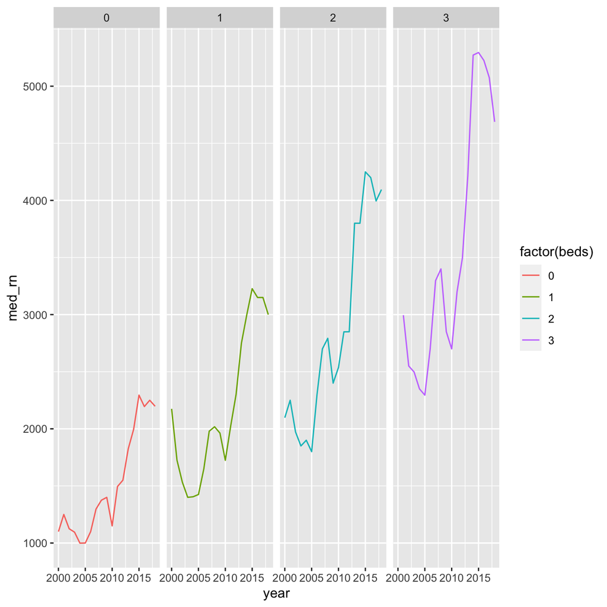

```r
rent_sf<- rent %>%
          filter(city =="san francisco", beds <= 3) %>%
          group_by(year, beds) %>%
          summarise(med_rn = median(price))

ggplot(rent_sf, aes(x=year, y=med_rn, color= factor(beds)))+geom_line()+facet_grid(~beds)
```

```r
filtered_beds_0_2018 <- rent %>% group_by(beds,year) %>% filter(city =='san francisco',beds == 0, year ==2018)
head(filtered_beds_0_2018)
```

```
## # A tibble: 6 × 17
## # Groups:   beds, year [1]
##   post_id        date  year nhood   city  county price  beds baths  sqft room_…¹
##   <chr>         <dbl> <dbl> <chr>   <chr> <chr>  <dbl> <dbl> <dbl> <dbl>   <dbl>
## 1 6580981486 20180510  2018 castro  san … san f…  2250     0    NA    NA       0
## 2 6480252497 20180201  2018 CCSF    san … san f…  1800     0     1    NA       0
## 3 6584911622 20180510  2018 CCSF    san … san f…   900     0     1   150       0
## 4 6503872328 20180220  2018 civic … san … san f…   755     0    NA    NA       0
## 5 6499200906 20180301  2018 civic … san … san f…  1975     0    NA   300       0
## 6 6488645253 20180208  2018 civic … san … san f…  2395     0    NA   450       0
## # … with 6 more variables: address <chr>, lat <dbl>, lon <dbl>, title <chr>,
## #   descr <chr>, details <chr>, and abbreviated variable name ¹room_in_apt
```

```r
top_twelve_data <- rent %>%
  count(city) %>% #to count number of classifieds in each city
  arrange(desc(n)) %>%
  slice(1:12)
top_twelve_cities <- as.vector(top_twelve_data$city)
top_twelve_cities
```

```
##  [1] "san francisco" "san jose"      "oakland"       "santa rosa"
##  [5] "santa cruz"    "san mateo"     "sunnyvale"     "mountain view"
##  [9] "berkeley"      "santa clara"   "palo alto"     "union city"
```

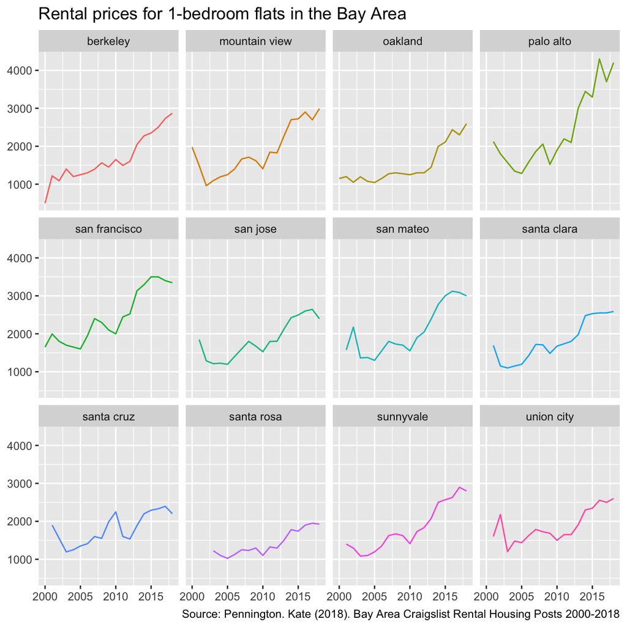

```r
rent %>%
  filter(city %in% top_twelve_cities) %>%
  group_by(year, city) %>%
  summarize(median_price = median(price)) %>%
ggplot(aes(year, median_price, color = factor(city))) +
  geom_line() +
  facet_wrap(vars(city)) +
  labs(
  title = "Rental prices for 1-bedroom flats in the Bay Area",
  x = NULL,
  y = NULL,
  caption = "Source: Pennington. Kate (2018). Bay Area Craigslist Rental Housing Posts 2000-2018") +
  theme(legend.position = "None")
```

The data set shows us that San Francisco has the maximum percentage listings, precisely 4x listings more than San Jose, the second highest listings city. This is valid since most listing are in the densely populated area of San Francisco rather than in the suburbs in the vicinity. Moreover, its vicinity to Silicon Valley makes it a hub for residences.

# 2 Analysis of movies- IMDB dataset

```r
movies <- read.csv(here::here("data", "movies.csv"))
```

## 2.1 Use your data import, inspection, and cleaning skills to answer the following:

- Are there any missing values (NAs)? Are all entries distinct or are there duplicate entries?

```r
count_NA <- sum(is.na(movies)) #counting all the NAs
count_NA
duplicated_count <- sum(duplicated(movies)) #counting all the duplicated
duplicated_count
```

[output not shown]

- Produce a table with the count of movies by genre, ranked in descending order. We can see that Comedy has the most movies listed, followed by Action. Whereas Thriller only has one movie listed.

```r
movies <- read.csv(here::here("data", "movies.csv"))
movie_table<- movies %>%group_by(genre) %>% count(genre) #grouping by genre, then counting.
arrange(movie_table, desc(n))
```

```
## # A tibble: 17 × 2
## # Groups:   genre [17]
##    genre           n
##    <chr>       <int>
##  1 Comedy        848
##  2 Action        738
##  3 Drama         498
##  4 Adventure     288
##  5 Crime         202
##  6 Biography     135
##  7 Horror        131
##  8 Animation      35
##  9 Fantasy        28
## 10 Documentary    25
## 11 Mystery        16
## 12 Sci-Fi          7
## 13 Family          3
## 14 Musical         2
## 15 Romance         2
## 16 Western         2
## 17 Thriller        1
```

- Produce a table with the average gross earning and budget (`gross` and `budget`) by genre. Calculate a variable `return_on_budget` which shows how many $ did a movie make at the box office for each $ of its budget. Ranked genres by this `return_on_budget` in descending order.

```r
movies %>%
  group_by(genre) %>%
  summarize(return_on_budget = (mean(gross)/mean(budget))) %>%  #creating a new column called return_on _budget
  arrange(desc(return_on_budget))
```

```
## # A tibble: 17 × 2
##    genre       return_on_budget
##    <chr>                  <dbl>
##  1 Musical             28.9
##  2 Family              10.1
##  3 Western              6.01
##  4 Documentary          2.95
##  5 Horror               2.79
##  6 Fantasy              2.41
##  7 Comedy               1.74
##  8 Mystery              1.72
##  9 Animation            1.60
## 10 Biography            1.58
## 11 Adventure            1.45
## 12 Drama                1.43
## 13 Crime                1.41
## 14 Romance              1.25
## 15 Action               1.21
## 16 Sci-Fi               1.08
## 17 Thriller             0.00823
```

- Produce a table that shows the top 15 directors who have created the highest gross revenue in the box office.

We can see that Steven Spielberg had a highest sum of gross revenue.

```r
movies %>% group_by(director) %>% summarize(sum = sum(gross),mean = mean(gross), median = median(gross), std = sd(gross)) %>%  arrange(desc(sum)) %>% slice_head(n = 15)
```

```
## # A tibble: 15 × 5
##    director                 sum       mean     median        std
##    <chr>                  <dbl>      <dbl>      <dbl>      <dbl>
##  1 Steven Spielberg  4014061704 174524422. 164435221  101421051.
##  2 Michael Bay       2231242537 171634041. 138396624  127161579.
##  3 Tim Burton        2071275480 129454718.  76519172  108726924.
##  4 Sam Raimi         2014600898 201460090. 234903076  162126632.
##  5 James Cameron     1909725910 318287652. 175562880. 309171337.
##  6 Christopher Nolan 1813227576 226653447  196667606. 187224133.
##  7 George Lucas      1741418480 348283696  380262555  146193880.
##  8 Robert Zemeckis   1619309108 124562239. 100853835   91300279.
##  9 Clint Eastwood    1378321100  72543216.  46700000   75487408.
## 10 Francis Lawrence  1358501971 271700394. 281666058  135437020.
## 11 Ron Howard        1335988092 111332341  101587923   81933761.
## 12 Gore Verbinski    1329600995 189942999. 123207194  154473822.
## 13 Andrew Adamson    1137446920 284361730  279680930. 120895765.
## 14 Shawn Levy        1129750988 102704635.  85463309   65484773.
## 15 Ridley Scott      1128857598  80632686.  47775715   68812285.
```

- Finally, ratings. Produce a table that describes how ratings are distributed by genre. We don’t want just the mean, but also, min, max, median, SD and some kind of a histogram or density graph that visually shows how ratings are distributed.

```r
 movies %>%
  group_by(genre) %>%
  skim()
```

Data summary

| Name | Piped data |
| --- | --- |
| Number of rows | 2961 |
| Number of columns | 11 |
| _______________________ |  |
| Column type frequency: |  |
| character | 2 |
| numeric | 8 |
| ________________________ |  |
| Group variables | genre |

**Variable type: character**

| skim_variable | genre | n_missing | complete_rate | min | max | empty | n_unique | whitespace |
| --- | --- | --- | --- | --- | --- | --- | --- | --- |
| title | Action | 0 | 1 | 3 | 55 | 0 | 719 | 0 |
| title | Adventure | 0 | 1 | 2 | 62 | 0 | 281 | 0 |
| title | Animation | 0 | 1 | 8 | 39 | 0 | 35 | 0 |
| title | Biography | 0 | 1 | 2 | 58 | 0 | 135 | 0 |
| title | Comedy | 0 | 1 | 2 | 83 | 0 | 844 | 0 |
| title | Crime | 0 | 1 | 4 | 40 | 0 | 198 | 0 |
| title | Documentary | 0 | 1 | 4 | 41 | 0 | 25 | 0 |
| title | Drama | 0 | 1 | 1 | 50 | 0 | 484 | 0 |
| title | Family | 0 | 1 | 14 | 26 | 0 | 3 | 0 |
| title | Fantasy | 0 | 1 | 5 | 45 | 0 | 26 | 0 |
| title | Horror | 0 | 1 | 3 | 42 | 0 | 128 | 0 |
| title | Musical | 0 | 1 | 6 | 19 | 0 | 2 | 0 |
| title | Mystery | 0 | 1 | 7 | 17 | 0 | 15 | 0 |
| title | Romance | 0 | 1 | 16 | 21 | 0 | 2 | 0 |
| title | Sci-Fi | 0 | 1 | 8 | 26 | 0 | 7 | 0 |
| title | Thriller | 0 | 1 | 9 | 9 | 0 | 1 | 0 |
| title | Western | 0 | 1 | 10 | 23 | 0 | 2 | 0 |
| director | Action | 0 | 1 | 3 | 32 | 0 | 424 | 0 |
| director | Adventure | 0 | 1 | 7 | 25 | 0 | 215 | 0 |
| director | Animation | 0 | 1 | 8 | 18 | 0 | 31 | 0 |
| director | Biography | 0 | 1 | 9 | 20 | 0 | 112 | 0 |
| director | Comedy | 0 | 1 | 7 | 25 | 0 | 510 | 0 |
| director | Crime | 0 | 1 | 8 | 20 | 0 | 151 | 0 |
| director | Documentary | 0 | 1 | 8 | 18 | 0 | 23 | 0 |
| director | Drama | 0 | 1 | 3 | 26 | 0 | 350 | 0 |
| director | Family | 0 | 1 | 13 | 16 | 0 | 3 | 0 |
| director | Fantasy | 0 | 1 | 9 | 20 | 0 | 24 | 0 |
| director | Horror | 0 | 1 | 7 | 24 | 0 | 97 | 0 |
| director | Musical | 0 | 1 | 14 | 14 | 0 | 2 | 0 |
| director | Mystery | 0 | 1 | 9 | 18 | 0 | 14 | 0 |
| director | Romance | 0 | 1 | 10 | 12 | 0 | 2 | 0 |
| director | Sci-Fi | 0 | 1 | 10 | 19 | 0 | 7 | 0 |
| director | Thriller | 0 | 1 | 12 | 12 | 0 | 1 | 0 |
| director | Western | 0 | 1 | 10 | 14 | 0 | 2 | 0 |

**Variable type: numeric**

| skim_variable | genre | n_missing | complete_rate | mean | sd | p0 | p25 | p50 | p75 | p100 | hist |
| --- | --- | --- | --- | --- | --- | --- | --- | --- | --- | --- | --- |
| year | Action | 0 | 1 | 2.00e+03 | 8.73e+00 | 1.96e+03 | 2.00e+03 | 2.00e+03 | 2.01e+03 | 2.02e+03 | ▁▁▂▇▇ |
| year | Adventure | 0 | 1 | 2.00e+03 | 1.10e+01 | 1.94e+03 | 2.00e+03 | 2.01e+03 | 2.01e+03 | 2.02e+03 | ▁▁▁▃▇ |
| year | Animation | 0 | 1 | 2.00e+03 | 1.67e+01 | 1.94e+03 | 2.00e+03 | 2.01e+03 | 2.01e+03 | 2.02e+03 | ▁▁▁▂▇ |
| year | Biography | 0 | 1 | 2.00e+03 | 1.09e+01 | 1.95e+03 | 2.00e+03 | 2.00e+03 | 2.01e+03 | 2.02e+03 | ▁▁▁▃▇ |
| year | Comedy | 0 | 1 | 2.00e+03 | 8.85e+00 | 1.93e+03 | 2.00e+03 | 2.00e+03 | 2.01e+03 | 2.02e+03 | ▁▁▁▃▇ |
| year | Crime | 0 | 1 | 2.00e+03 | 1.17e+01 | 1.92e+03 | 2.00e+03 | 2.00e+03 | 2.01e+03 | 2.02e+03 | ▁▁▁▂▇ |
| year | Documentary | 0 | 1 | 2.01e+03 | 9.38e+00 | 1.97e+03 | 2.00e+03 | 2.01e+03 | 2.01e+03 | 2.01e+03 | ▁▁▁▂▇ |
| year | Drama | 0 | 1 | 2.00e+03 | 9.76e+00 | 1.94e+03 | 2.00e+03 | 2.00e+03 | 2.01e+03 | 2.02e+03 | ▁▁▁▃▇ |
| year | Family | 0 | 1 | 1.99e+03 | 1.10e+01 | 1.98e+03 | 1.99e+03 | 1.99e+03 | 2.00e+03 | 2.00e+03 | ▇▁▇▁▇ |
| year | Fantasy | 0 | 1 | 2.00e+03 | 1.17e+01 | 1.98e+03 | 1.99e+03 | 1.99e+03 | 2.01e+03 | 2.01e+03 | ▅▇▂▁▆ |
| year | Horror | 0 | 1 | 2.00e+03 | 1.13e+01 | 1.96e+03 | 2.00e+03 | 2.01e+03 | 2.01e+03 | 2.02e+03 | ▁▁▂▅▇ |
| year | Musical | 0 | 1 | 1.95e+03 | 3.46e+01 | 1.93e+03 | 1.94e+03 | 1.95e+03 | 1.97e+03 | 1.98e+03 | ▇▁▁▁▇ |
| year | Mystery | 0 | 1 | 2.01e+03 | 8.48e+00 | 1.98e+03 | 2.00e+03 | 2.01e+03 | 2.01e+03 | 2.02e+03 | ▁▁▂▅▇ |
| year | Romance | 0 | 1 | 2.01e+03 | 1.41e+00 | 2.01e+03 | 2.01e+03 | 2.01e+03 | 2.01e+03 | 2.01e+03 | ▇▁▁▁▇ |
| year | Sci-Fi | 0 | 1 | 2.00e+03 | 1.27e+01 | 1.98e+03 | 1.99e+03 | 2.00e+03 | 2.01e+03 | 2.02e+03 | ▅▁▂▇▂ |
| year | Thriller | 0 | 1 | 2.01e+03 | NA | 2.01e+03 | 2.01e+03 | 2.01e+03 | 2.01e+03 | 2.01e+03 | ▁▁▇▁▁ |
| year | Western | 0 | 1 | 2.00e+03 | 1.56e+01 | 1.98e+03 | 1.99e+03 | 2.00e+03 | 2.00e+03 | 2.01e+03 | ▇▁▁▁▇ |
| duration | Action | 0 | 1 | 1.13e+02 | 2.01e+01 | 7.90e+01 | 1.00e+02 | 1.10e+02 | 1.24e+02 | 2.15e+02 | ▇▇▂▁▁ |
| duration | Adventure | 0 | 1 | 1.06e+02 | 2.64e+01 | 6.30e+01 | 9.00e+01 | 1.00e+02 | 1.15e+02 | 3.25e+02 | ▇▂▁▁▁ |
| duration | Animation | 0 | 1 | 8.81e+01 | 1.03e+01 | 6.80e+01 | 8.05e+01 | 8.80e+01 | 9.40e+01 | 1.11e+02 | ▃▅▇▃▂ |
| duration | Biography | 0 | 1 | 1.28e+02 | 2.72e+01 | 8.50e+01 | 1.08e+02 | 1.23e+02 | 1.35e+02 | 2.40e+02 | ▆▇▂▁▁ |
| duration | Comedy | 0 | 1 | 1.02e+02 | 1.30e+01 | 3.70e+01 | 9.30e+01 | 1.00e+02 | 1.09e+02 | 1.53e+02 | ▁▁▇▃▁ |
| duration | Crime | 0 | 1 | 1.17e+02 | 2.78e+01 | 5.30e+01 | 1.01e+02 | 1.14e+02 | 1.25e+02 | 3.30e+02 | ▆▇▁▁▁ |
| duration | Documentary | 0 | 1 | 1.05e+02 | 2.96e+01 | 8.00e+01 | 9.00e+01 | 9.30e+01 | 1.11e+02 | 2.15e+02 | ▇▂▁▁▁ |
| duration | Drama | 0 | 1 | 1.17e+02 | 2.49e+01 | 7.60e+01 | 1.02e+02 | 1.12e+02 | 1.28e+02 | 2.89e+02 | ▇▅▁▁▁ |
| duration | Family | 0 | 1 | 1.05e+02 | 1.41e+01 | 9.20e+01 | 9.75e+01 | 1.03e+02 | 1.12e+02 | 1.20e+02 | ▇▇▁▁▇ |
| duration | Fantasy | 0 | 1 | 1.04e+02 | 1.77e+01 | 7.20e+01 | 9.05e+01 | 1.00e+02 | 1.08e+02 | 1.55e+02 | ▂▇▃▁▁ |
| duration | Horror | 0 | 1 | 9.80e+01 | 1.23e+01 | 7.50e+01 | 9.00e+01 | 9.60e+01 | 1.03e+02 | 1.50e+02 | ▃▇▂▁▁ |
| duration | Musical | 0 | 1 | 1.05e+02 | 7.07e+00 | 1.00e+02 | 1.02e+02 | 1.05e+02 | 1.08e+02 | 1.10e+02 | ▇▁▁▁▇ |
| duration | Mystery | 0 | 1 | 1.10e+02 | 2.38e+01 | 8.50e+01 | 9.52e+01 | 1.01e+02 | 1.12e+02 | 1.74e+02 | ▇▅▁▁▁ |

[output cut: 106 more lines]

## 2.2 Use `ggplot` to answer the following

- Examine the relationship between `gross` and `cast_facebook_likes`. Produce a scatterplot and write one sentence discussing whether the number of facebook likes that the cast has received is likely to be a good predictor of how much money a movie will make at the box office. What variable are you going to map to the Y- and X- axes.

We put “cast_facebook_likes” into the X axis and “gross” to the Y axis. There is a slight positive correlation between ‘gross’ and ‘cast_facebook_like’, although there exist many outliers, such as when likes is less than 100. Therefore, the cast is not likely to be a good predictor. However, many data points lies outside the a line of best fit, therefore, we cannot say with good confidence that it is a good predictor.

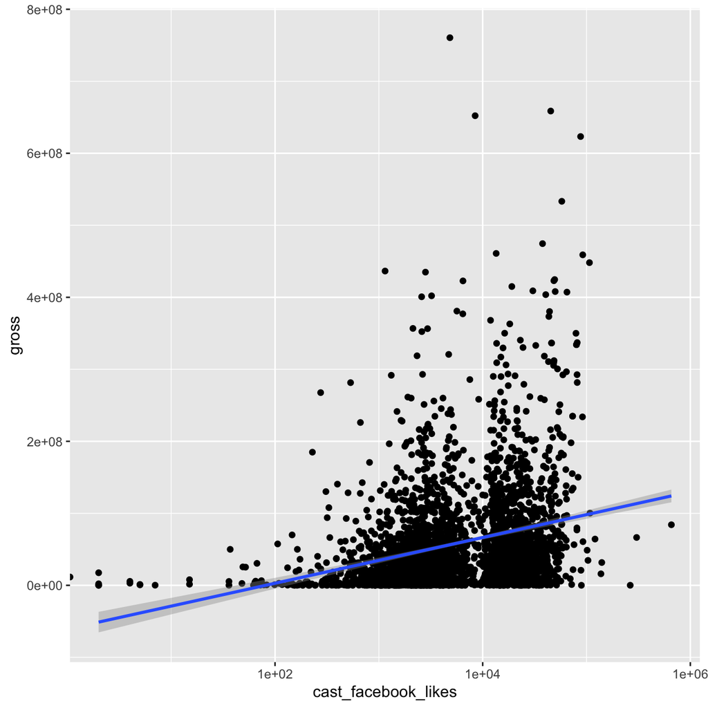

```r
ggplot(movies, aes(x=cast_facebook_likes, y=gross))+ geom_point() +scale_x_log10() +geom_smooth(method ='lm')
```

- Examine the relationship between `gross` and `budget`. Produce a scatterplot and write one sentence discussing whether budget is likely to be a good predictor of how much money a movie will make at the box office.

Budget appears to be a good predictor of grossing, since the graph shows shows a positive correlation. Although when the budget is less than 1 million dollars, it is not a good predictor.

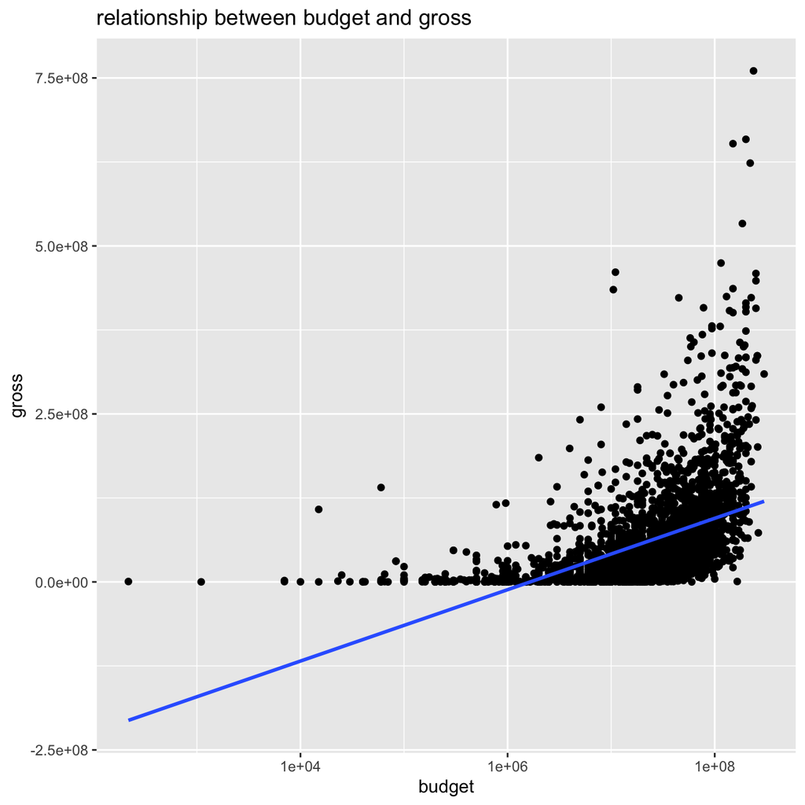

```r
  ggplot(movies, aes(x=budget, y=gross))+ geom_point() + geom_smooth(method='lm', se=FALSE)+ scale_x_log10() + labs(title='relationship between budget and gross')
```

- Examine the relationship between `gross` and `rating`. Produce a scatterplot, faceted by `genre` and discuss whether IMDB ratings are likely to be a good predictor of how much money a movie will make at the box office. Is there anything strange in this dataset?

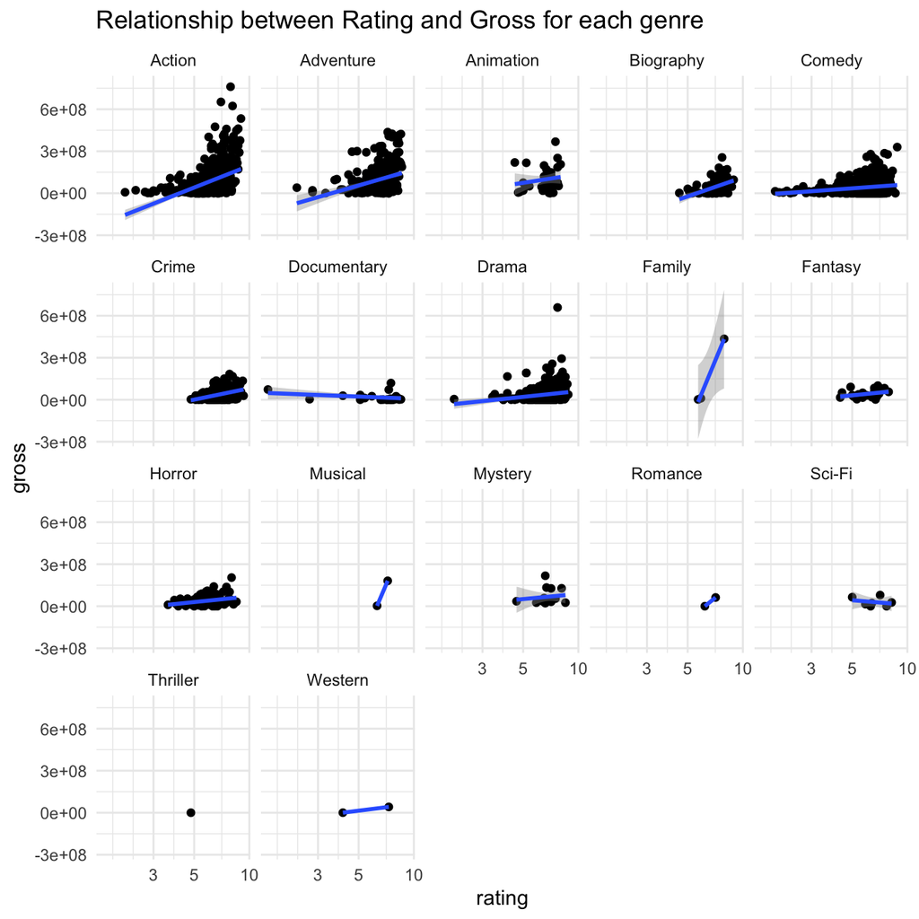

```r
  ggplot(movies, aes(x=rating, y=gross))+ geom_point() +geom_smooth(method='lm')+ scale_x_log10() + facet_wrap(~genre) + theme_minimal() + labs(title = 'Relationship between Rating and Gross for each genre')
```

# 3 Returns of financial stocks

```r
nyse <- read_csv(here::here("data","nyse.csv"))
```

Based on this dataset, create a table and a bar plot that shows the number of companies per sector, in descending order

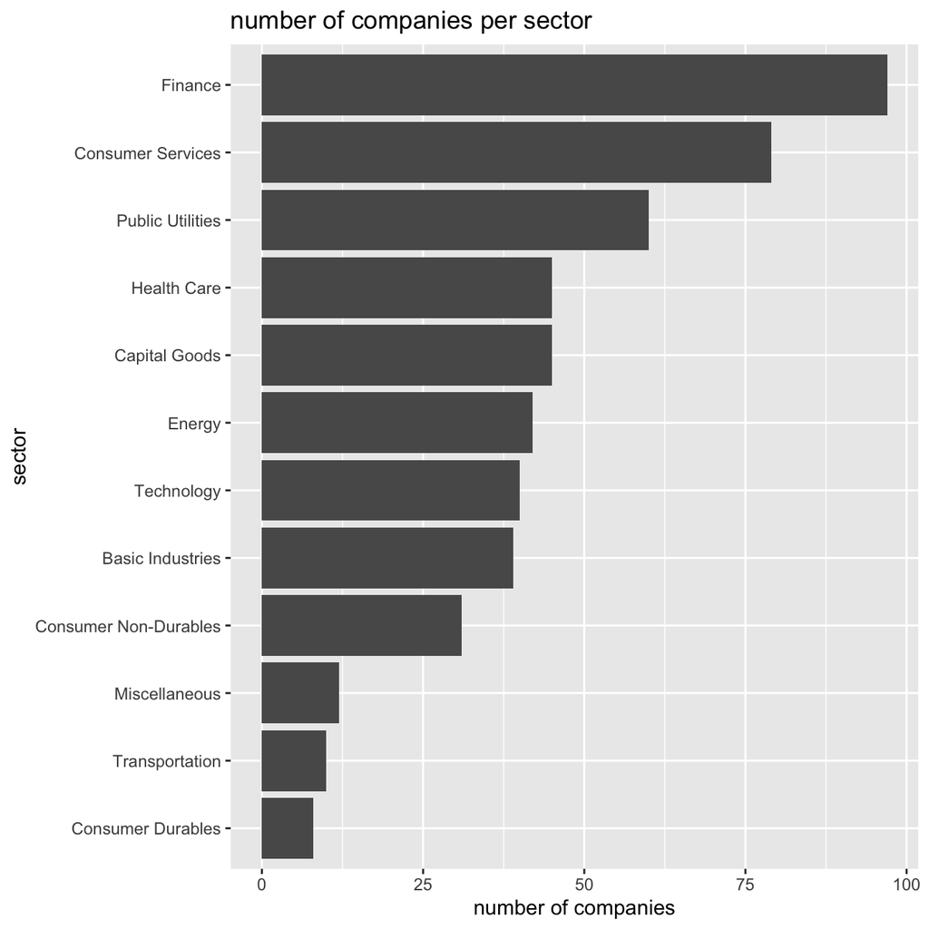

```r
companies_per_sector <- nyse %>%
  group_by(sector) %>%
  summarise(n_companies = n()) %>%
  arrange(desc(n_companies))

ggplot(data = companies_per_sector, mapping = aes(x = n_companies, y = fct_reorder(sector,n_companies))) +
  geom_col() +
  labs(title = "number of companies per sector", x = "number of companies", y = "sector")
```

Next, let’s choose some stocks and their ticker symbols and download some data. You **MUST** choose 6 different stocks from the ones listed below; You should, however, add `SPY` which is the SP500 ETF (Exchange Traded Fund).

```r
myStocks <- c("AAPL","JPM","DIS","DPZ","ANF","TSLA","XOM","SPY" ) %>%
  tq_get(get  = "stock.prices",
         from = "2011-01-01",
         to   = "2022-08-31") %>% group_by(symbol)

glimpse(myStocks) # examine the structure of the resulting data frame
```

```
## Rows: 23,480
## Columns: 8
## Groups: symbol [8]
## $ symbol   <chr> "AAPL", "AAPL", "AAPL", "AAPL", "AAPL", "AAPL", "AAPL", "AAPL…
## $ date     <date> 2011-01-03, 2011-01-04, 2011-01-05, 2011-01-06, 2011-01-07, …
## $ open     <dbl> 11.6, 11.9, 11.8, 12.0, 11.9, 12.1, 12.3, 12.3, 12.3, 12.4, 1…
## $ high     <dbl> 11.8, 11.9, 11.9, 12.0, 12.0, 12.3, 12.3, 12.3, 12.4, 12.4, 1…
## $ low      <dbl> 11.6, 11.7, 11.8, 11.9, 11.9, 12.0, 12.1, 12.2, 12.3, 12.3, 1…
## $ close    <dbl> 11.8, 11.8, 11.9, 11.9, 12.0, 12.2, 12.2, 12.3, 12.3, 12.4, 1…
## $ volume   <dbl> 4.45e+08, 3.09e+08, 2.56e+08, 3.00e+08, 3.12e+08, 4.49e+08, 4…
## $ adjusted <dbl> 10.05, 10.10, 10.18, 10.18, 10.25, 10.44, 10.42, 10.50, 10.54…
```

Financial performance analysis depend on returns; If I buy a stock today for 100 and I sell it tomorrow for 101.75, my one-day return, assuming no transaction costs, is 1.75%. So given the adjusted closing prices, our first step is to calculate daily and monthly returns.

```r
#calculate daily returns
myStocks_returns_daily <- myStocks %>%
  tq_transmute(select     = adjusted,
               mutate_fun = periodReturn,
               period     = "daily",
               type       = "log",
               col_rename = "daily_returns",
               cols = c(nested.col))

#calculate monthly  returns
myStocks_returns_monthly <- myStocks %>%
  tq_transmute(select     = adjusted,
               mutate_fun = periodReturn,
               period     = "monthly",
               type       = "arithmetic",
               col_rename = "monthly_returns",
               cols = c(nested.col))

#calculate yearly returns
myStocks_returns_annual <- myStocks %>%
  group_by(symbol) %>%
  tq_transmute(select     = adjusted,
               mutate_fun = periodReturn,
               period     = "yearly",
               type       = "arithmetic",
               col_rename = "yearly_returns",
               cols = c(nested.col))
```

Create a table where you summarise monthly returns for each of the stocks and `SPY`; min, max, median, mean, SD.

```r
summarise_monthly_returns <- myStocks_returns_monthly %>%
  summarize(min = min(monthly_returns), max = max(monthly_returns), median = median(monthly_returns), mean = mean(monthly_returns), sd = sd(monthly_returns))
```

Plot a density plot, using `geom_density()`, for each of the stocks

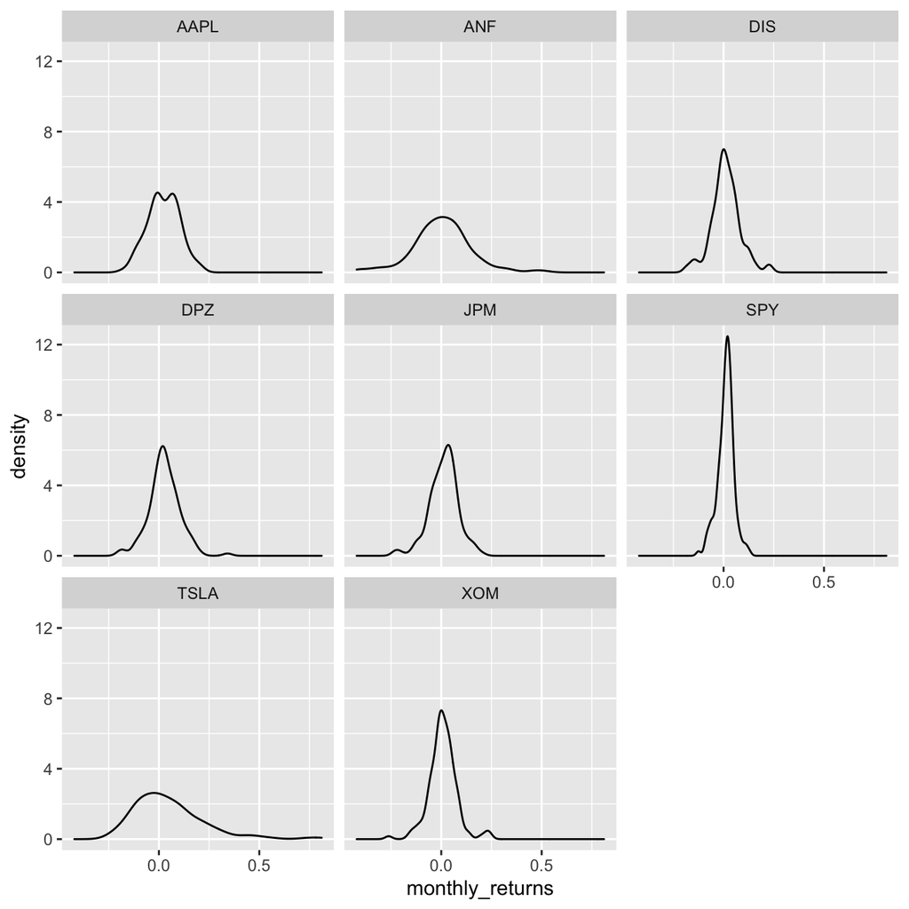

```r
ggplot(data = myStocks_returns_monthly,aes (x = monthly_returns)) +
  geom_density() +
  facet_wrap(~symbol)
```

Finally, make a plot that shows the expected monthly return (mean) of a stock on the Y axis and the risk (standard deviation) in the X-axis. Please use `ggrepel::geom_text_repel()` to label each stock

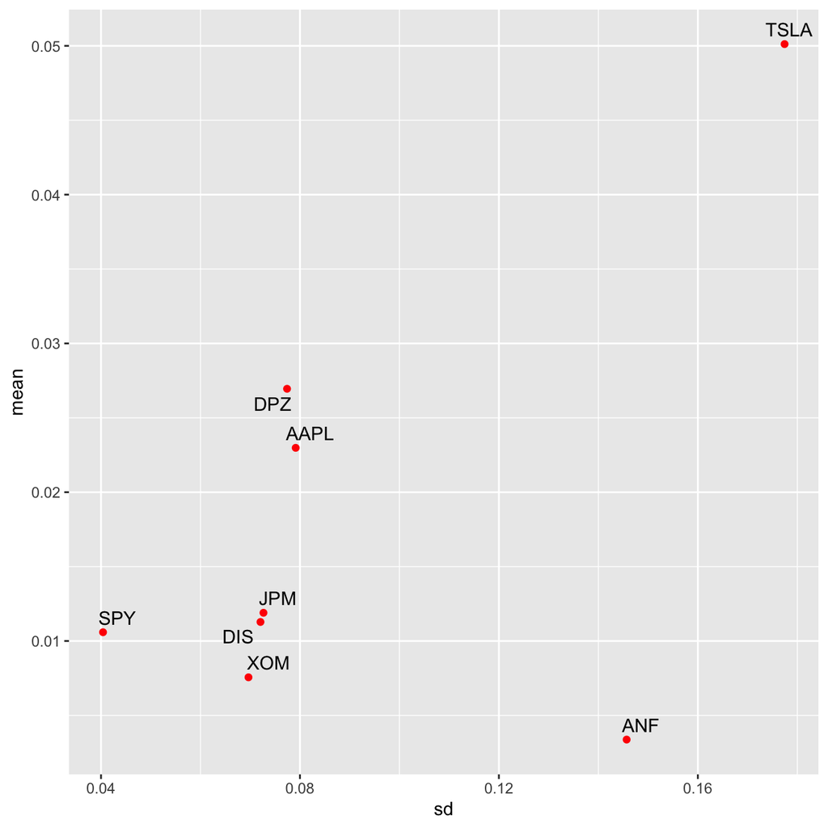

```r
ggplot(summarise_monthly_returns) +
  aes(x = sd, y = mean, label = symbol) +
  geom_point(color = "red") +
  ggrepel::geom_text_repel()
```

What can you infer from this plot? Are there any stocks which, while being riskier, do not have a higher expected return?

# 4 On your own: Spotify

```r
spotify_songs <- readr::read_csv('https://raw.githubusercontent.com/rfordatascience/tidytuesday/master/data/2020/2020-01-21/spotify_songs.csv')
```

Produce a one-page summary describing this dataset. Here is a non-exhaustive list of questions:

1. What is the distribution of songs’ popularity (`track_popularity`). Does it look like a Normal distribution?

The track popularity is not normally distributed. As it stands by the graph, the “normal pattern” is lost as we take a look to the lower values (from 0 to 10): these values have an higher probability than the values corresponding to the center of the bell curve. Hence, the distribution is not symmetric, having more probability concentrated in the left side of the curve.

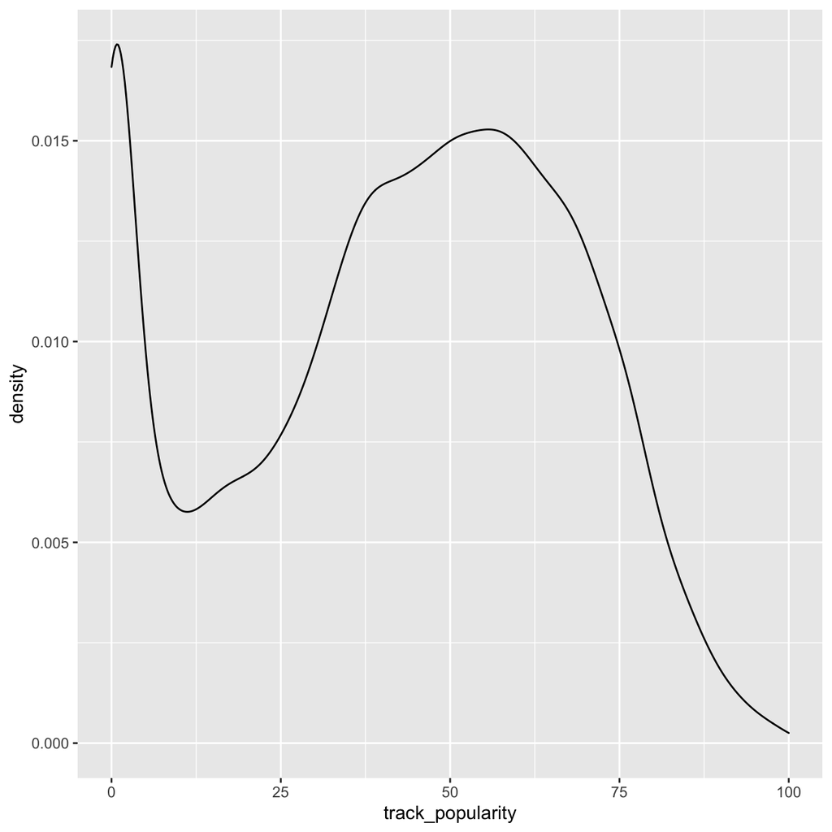

```r
ggplot(spotify_songs, aes(x=track_popularity)) + geom_density()
```

2. There are 12 [audio features](https://developer.spotify.com/documentation/web-api/reference/object-model/#audio-features-object) for each track, including confidence measures like `acousticness`, `liveness`, `speechines`and `instrumentalness`, perceptual measures like `energy`, `loudness`, `danceability` and `valence` (positiveness), and descriptors like `duration`, `tempo`, `key`, and `mode`. How are they distributed? can you roughly guess which of these variables is closer to Normal just by looking at summary statistics?

By the summary given by the skim function, we can take a look to the histogram of the variables. Generally, the plotted variables have an irregular and skewed distribution. Although, it is possible to see that the tempo and the valence variables actually have a distribution that is similar to a normal one. Comparing those two variables, the closest to a normally distributed one is the tempo. On the other hand, if we had to look at the summary statistics in order to evaluate the similarity to the normal distribution, we could take a look to the difference between the median and the mean: this value is a good inidicator of the skewness of the distribution, since the furthest the median is from the mean, the more skewed is the distribution. In fact, we can see how the two variables with a normal-like distribution (tempo and valence) also have a mean close to the median.

```r
  skim(select(spotify_songs,track_name,acousticness, liveness, speechiness,instrumentalness,energy, loudness, danceability, valence, duration_ms, tempo, key,mode))
```

Data summary

| Name | select(…) |
| --- | --- |
| Number of rows | 32833 |
| Number of columns | 13 |
| _______________________ |  |
| Column type frequency: |  |
| character | 1 |
| numeric | 12 |
| ________________________ |  |
| Group variables | None |

**Variable type: character**

| skim_variable | n_missing | complete_rate | min | max | empty | n_unique | whitespace |
| --- | --- | --- | --- | --- | --- | --- | --- |
| track_name | 5 | 1 | 1 | 144 | 0 | 23449 | 0 |

**Variable type: numeric**

| skim_variable | n_missing | complete_rate | mean | sd | p0 | p25 | p50 | p75 | p100 | hist |
| --- | --- | --- | --- | --- | --- | --- | --- | --- | --- | --- |
| acousticness | 0 | 1 | 0.18 | 0.22 | 0.0 | 0.02 | 0.08 | 0.26 | 9.90e-01 | ▇▂▁▁▁ |
| liveness | 0 | 1 | 0.19 | 0.15 | 0.0 | 0.09 | 0.13 | 0.25 | 1.00e+00 | ▇▃▁▁▁ |
| speechiness | 0 | 1 | 0.11 | 0.10 | 0.0 | 0.04 | 0.06 | 0.13 | 9.20e-01 | ▇▂▁▁▁ |
| instrumentalness | 0 | 1 | 0.08 | 0.22 | 0.0 | 0.00 | 0.00 | 0.00 | 9.90e-01 | ▇▁▁▁▁ |
| energy | 0 | 1 | 0.70 | 0.18 | 0.0 | 0.58 | 0.72 | 0.84 | 1.00e+00 | ▁▁▅▇▇ |
| loudness | 0 | 1 | -6.72 | 2.99 | -46.5 | -8.17 | -6.17 | -4.64 | 1.27e+00 | ▁▁▁▂▇ |
| danceability | 0 | 1 | 0.65 | 0.15 | 0.0 | 0.56 | 0.67 | 0.76 | 9.80e-01 | ▁▁▃▇▃ |
| valence | 0 | 1 | 0.51 | 0.23 | 0.0 | 0.33 | 0.51 | 0.69 | 9.90e-01 | ▃▇▇▇▃ |
| duration_ms | 0 | 1 | 225799.81 | 59834.01 | 4000.0 | 187819.00 | 216000.00 | 253585.00 | 5.18e+05 | ▁▇▇▁▁ |
| tempo | 0 | 1 | 120.88 | 26.90 | 0.0 | 99.96 | 121.98 | 133.92 | 2.39e+02 | ▁▂▇▂▁ |
| key | 0 | 1 | 5.37 | 3.61 | 0.0 | 2.00 | 6.00 | 9.00 | 1.10e+01 | ▇▂▅▅▆ |
| mode | 0 | 1 | 0.57 | 0.50 | 0.0 | 0.00 | 1.00 | 1.00 | 1.00e+00 | ▆▁▁▁▇ |

4. Is there any relationship between `valence` and `track_popularity`? `danceability` and `track_popularity` ?

As we can see by the two graphs, it is possible to see how the correlation between valence and track popularity as well as the correlation between danceability and track popularity is practically absent. Hence, there is no correlation between those variables.

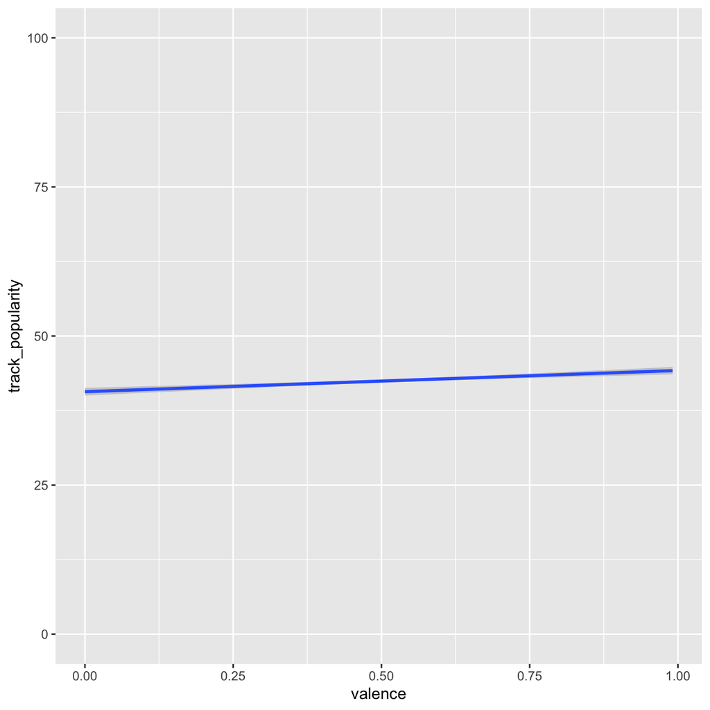

```r
ggplot(spotify_songs, aes(x=valence, y=track_popularity))+ geom_smooth(method= 'lm', se=TRUE) + expand_limits(y=c(0,100))
```

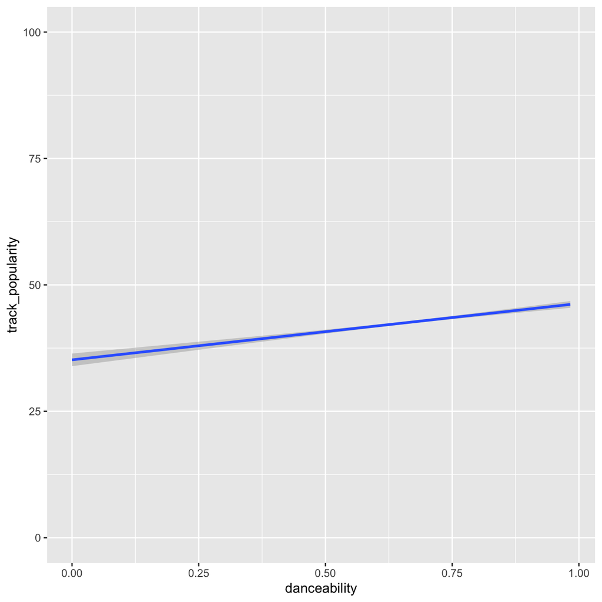

```r
ggplot(spotify_songs, aes(x=danceability, y=track_popularity)) + geom_smooth(method= 'lm', se=TRUE) + expand_limits(y=c(0,100))
```

5. `mode` indicates the modality (major or minor) of a track, the type of scale from which its melodic content is derived. Major is represented by 1 and minor is 0. Do songs written on a major scale have higher `danceability` compared to those in minor scale? What about `track_popularity`?

Given the relative difference (the percentage difference) between the two average danceabilities and the two average popularities, it would be risky to say that changing the mode affects these two values. Since the two averages for both values are really close to each other, it might be more technically correct to say that changing the mode doesn’t affect neither the danceability nor the track popularity.

```r
modality_and_danceability <- spotify_songs %>%
  group_by(mode) %>%
  summarise(average_danceability=mean(danceability))

modality_and_danceability
```

```
## # A tibble: 2 × 2
##    mode average_danceability
##   <dbl>                <dbl>
## 1     0                0.665
## 2     1                0.647
```

```r
modality_and_popularity <- spotify_songs %>%
  group_by(mode) %>%
  summarise(average_track_popularity=mean(track_popularity))

modality_and_popularity
```

```
## # A tibble: 2 × 2
##    mode average_track_popularity
##   <dbl>                    <dbl>
## 1     0                     42.2
## 2     1                     42.7
```

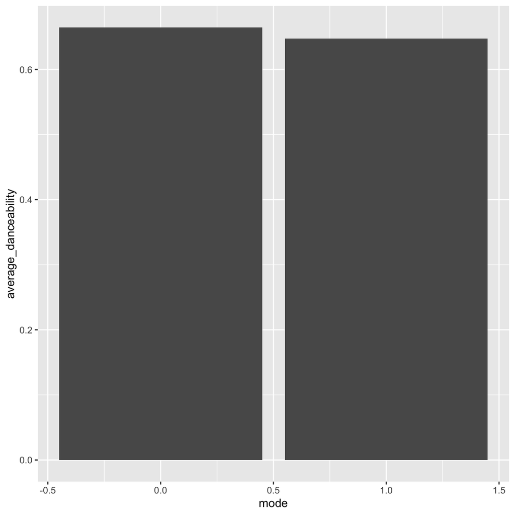

```r
ggplot(modality_and_danceability, aes(x=mode,y=average_danceability)) + geom_col()
```

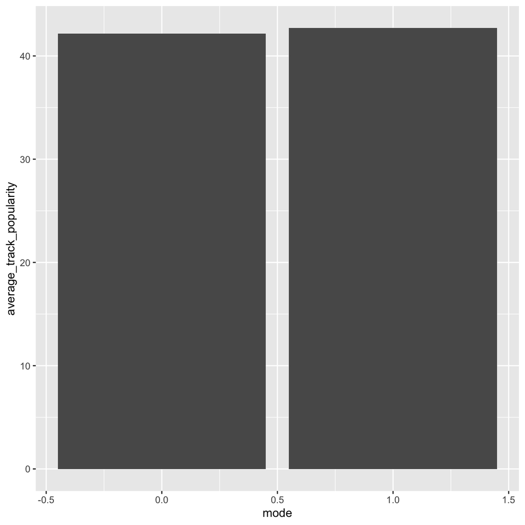

```r
ggplot(modality_and_popularity, aes(x=mode, y=average_track_popularity)) + geom_col()
```

# 5 Challenge 1: Replicating a chart

```r
rent_c <- readr::read_csv('https://raw.githubusercontent.com/rfordatascience/tidytuesday/master/data/2022/2022-07-05/rent.csv')
```

The purpose of this exercise is to reproduce a plot using your `dplyr` and `ggplot2` skills. It builds on exercise 1, the San Francisco rentals data.

You have to create a graph that calculates the cumulative % change for 0-, 1-1, and 2-bed flats between 2000 and 2018 for the top twelve cities in Bay Area, by number of ads that appeared in Craigslist. Your final graph should look like this

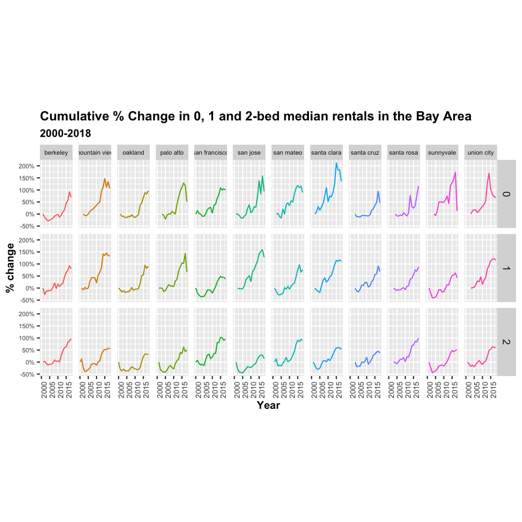

```r
filtered_top <- rent_c %>% group_by(city) %>% count(city, name = 'count_ads') %>% arrange(desc(count_ads)) %>% head(12) # finding top 12 city by ads

filtered_beds_012 <- rent_c %>% filter(beds <= 2) %>% group_by(year,beds,city) %>% mutate(median_price = median(price)) %>% select(city,beds,year,median_price) %>% distinct(city,.keep_all = TRUE) %>%  arrange(desc(beds),desc(city), year) %>% group_by(city,beds)%>%  mutate(percentage_change = (median_price/median_price[1]-1)) # finding percentage change of each #could be more optimal

merged_df  <- left_join(filtered_top, filtered_beds_012,by='city') # left join the two tables.

ggplot(merged_df, aes(x=year, y = percentage_change,colour=city))+geom_line()+facet_grid(beds~city) + theme(legend.position="none",aspect.ratio=25/12,text = element_text(size=rel(3)),title =element_text(size=10, face='bold'),axis.text.x=element_text(size=7, angle=90),
          strip.text.x = element_text(size=rel(2.4)),
          strip.text.y = element_text(size=rel(4))) + scale_y_continuous(labels = scales::percent_format(accuracy = 1)) + labs(y = '% change', x = 'Year', title= 'Cumulative % Change in 0, 1 and 2-bed median rentals in the Bay Area', subtitle= '2000-2018')
```

# 6 Challenge 2: 2016 California Contributors plots

As discussed in class, I would like you to reproduce the plot that shows the top ten cities in highest amounts raised in political contributions in California during the 2016 US Presidential election.

```r
# Make sure you use vroom() as it is significantly faster than read.csv()
CA_contributions <- vroom::vroom(here::here("data","CA_contributors_2016.csv"))

zipcodes<- vroom::vroom(here::here("data","zip_code_database.csv"))

CA_contributions$zip<- as.character(CA_contributions$zip)

CA_contributions_2016 <- left_join(CA_contributions, zipcodes, by="zip")

CA_contri_HC<- CA_contributions_2016 %>% filter(contb_date>"2015-12-31", cand_nm == c("Clinton, Hillary Rodham" )) %>% group_by(cand_nm, primary_city) %>% summarize(fund_per_city=sum(contb_receipt_amt)) %>% arrange(desc(fund_per_city))%>% slice_max(order_by = fund_per_city, n=10)

CA_contri_DT<- CA_contributions_2016 %>% filter(contb_date>"2015-12-31", cand_nm == c("Trump, Donald J.")) %>% group_by(cand_nm, primary_city) %>% summarize(fund_per_city=sum(contb_receipt_amt)) %>% arrange(desc(fund_per_city))%>% slice_max(order_by = fund_per_city, n=10)

HC_graph<- ggplot(CA_contri_HC, aes(x=fund_per_city, y=reorder(primary_city, fund_per_city)))+geom_col(width = 0.5, fill = "dark blue")+theme_minimal(base_size=10)+
  ggtitle("Clinton, Hillary Rodham")+theme(aspect.ratio = 1/1)

DT_graph<- ggplot(CA_contri_DT, aes(x=fund_per_city, y=reorder(primary_city, fund_per_city)))+geom_col(width = 0.5, fill = "red",position = position_dodge(0.1))+theme_minimal(base_size=10)+ggtitle("Trump, Donald J.")+theme(aspect.ratio = 1/1)
```

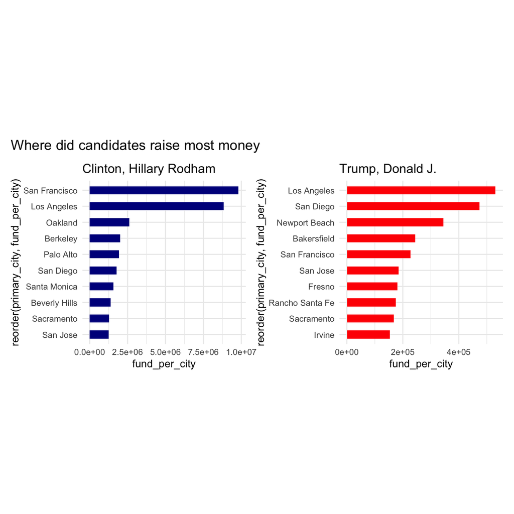

```r
HC_graph+DT_graph+plot_annotation(title = "Where did candidates raise most money")
```

# 7 Details